# CH 6 MD

Matthew Swanson

20190925

# 1 Summary

Chapter 6:

1. Simple Linear Regression
   - 1 x-variable (numerical)
   - 1 y-variable (always one)

Example:

- $x$: `bty_avg`
- $y$: `score`

On average, when you increase the `bty_avg` by one unit, the `score` will increase by `m`.

# 2 What is linear regression?

In regression we try to *predict* one variable based on one or more other variables.

- The variable we want to predit is called the response variable, denoted by $y$.
- The variable(s) that we use to predict $y$ is(are) called the predictor(s) or explanatory variable(s), denoted by $x$.

# 3 What do we cover?

- In this current chapter on basic regression, we’ll always have only one explanatory variable. In *Section 2*, this explanatory variable will be a single numerical explanatory variable $x$. This scenario is known as simple linear regression.
- In *Section 3*, this explanatory variable will be a categorical explanatory variable $x$.

# 4 One numerical explanatory variable

Example 3.1:

> Why do some professors and instructors at universities and colleges get high teaching evaluations from students while others don’t? What factors can explain these differences?

Researchers at the University of Texas in Austin, Texas (UT Austin) tried to answer this question: what factors can explain differences in instructor’s teaching evaluation scores? To this end, they collected information on $n=463$ instructors. A full description of the study can be found at openintro.org.

We’ll keep things simple for now and try to explain differences in instructor evaluation scores as a function of one numerical variable: their “‘beauty score’”.

- Could it be that instructors with higher beauty scores also have higher teaching evaluations?
- Could it be instead that instructors with higher beauty scores tend to have lower teaching evaluations?
- Or could it be there is no relationship between beauty score and teaching evaluations?

We’ll address these questions by modeling the relationship between these two variables with a particular kind of linear regression called *simple linear regression*. Simple linear regression is the most basic form of linear regression. With it we have

1. A numerical outcome variable $y$. In this case, their `teaching score`.
2. A single numerical explanatory variable $x$. In this case, their `beauty score`.

## 4.1 Exploratory data analysis

A crucial step before doing any kind of modeling or analysis is performing an exploratory data analysis, or EDA, of all our data.

1. Just looking at the raw values, in a spreadsheet for example.
2. Computing summary statistics likes means, medians, and standard deviations.
3. Creating data visualizations.

Okay… Let’s begin. The dataframe that we are working on is `evals` and it is in the `moderndive` library.

### 4.1.1 Looking at the raw values

Type `library(moderndive)` in the console and hit return, then type `View(evals)` in the console and hit return. Also type `?evals` in the console to see the description of the dataframe.

```r
library(moderndive)
library(dplyr)
#View(evals) #only works in the console
#?evals
glimpse(evals)
```

```
## Observations: 463
## Variables: 14
## $ ID           <int> 1, 2, 3, 4, 5, 6, 7, 8, 9, 10, 11, 12, 13, 14, 15, …
## $ prof_ID      <int> 1, 1, 1, 1, 2, 2, 2, 3, 3, 4, 4, 4, 4, 4, 4, 4, 4, …
## $ score        <dbl> 4.7, 4.1, 3.9, 4.8, 4.6, 4.3, 2.8, 4.1, 3.4, 4.5, 3…
## $ age          <int> 36, 36, 36, 36, 59, 59, 59, 51, 51, 40, 40, 40, 40,…
## $ bty_avg      <dbl> 5.000, 5.000, 5.000, 5.000, 3.000, 3.000, 3.000, 3.…
## $ gender       <fct> female, female, female, female, male, male, male, m…
## $ ethnicity    <fct> minority, minority, minority, minority, not minorit…
## $ language     <fct> english, english, english, english, english, englis…
## $ rank         <fct> tenure track, tenure track, tenure track, tenure tr…
## $ pic_outfit   <fct> not formal, not formal, not formal, not formal, not…
## $ pic_color    <fct> color, color, color, color, color, color, color, co…
## $ cls_did_eval <int> 24, 86, 76, 77, 17, 35, 39, 55, 111, 40, 24, 24, 17…
## $ cls_students <int> 43, 125, 125, 123, 20, 40, 44, 55, 195, 46, 27, 25,…
## $ cls_level    <fct> upper, upper, upper, upper, upper, upper, upper, up…
```

### 4.1.2 Computing summary statistics

Since we are only interested in one $x$ variable, namely, `bty_avg`, let’s select only the $y$ variable, score and `bty_avg`.

```r
evals_onex <- evals %>%
  select(score, bty_avg)
# View(evals_onex) # Only In the console, DO NOT run the View command here
glimpse(evals_onex)
```

```
## Observations: 463
## Variables: 2
## $ score   <dbl> 4.7, 4.1, 3.9, 4.8, 4.6, 4.3, 2.8, 4.1, 3.4, 4.5, 3.8, 4…
## $ bty_avg <dbl> 5.000, 5.000, 5.000, 5.000, 3.000, 3.000, 3.000, 3.333, …
```

Since both the outcome variable score and the explanatory variable `bty_avg` are numerical, we can compute summary statistics about them such as the mean, median, and standard deviation.

Let’s pipe this into the `skim()` function from the `skimr` package. This function quickly return the following summary information about each variable.

```r
library(skimr)
evals %>%
  select(score, bty_avg) %>%
  skim()
```

```
## Skim summary statistics
##  n obs: 463
##  n variables: 2
##
## ── Variable type:numeric ─────────────────────────────────────────────────────────────────────────────────────
##  variable missing complete   n mean   sd   p0  p25  p50 p75 p100     hist
##   bty_avg       0      463 463 4.42 1.53 1.67 3.17 4.33 5.5 8.17 ▂▅▅▇▃▃▂▁
##     score       0      463 463 4.17 0.54 2.3  3.8  4.3  4.6 5    ▁▁▂▃▅▇▇▆
```

```r
#Or, since we have already selected the variables, skim(evals_onex) would also works
```

Here, `p0` for example the 0th percentile: the value at which 0% of observations are smaller than it. This is also known as the minimum.

According to the histograms: variable score is skewed to the *left*, and the variable `bty_avg` is skewed to the *right*.

We get an idea of how the values in both variables are distributed. For example, the mean teaching score was *4.17* out of 5 whereas the mean beauty score was *4.42* out of 10. Furthermore, the middle 50% of teaching scores were between *3.8* and *4.6* () while the middle 50% of beauty scores were between *3.17* and *5.5* out of 10.

#### 4.1.2.1 Correlation Coefficient

Since we are considering the relationship between two numerical variables, it would be nice to have a summary statistic that simultaneously considers both variables. The correlation coefficient is a bivariate summary statistic that fits this bill.

A correlation coefficient is a quantitative expression between -1 and 1 that summarizes the strength of the linear relationship between two numerical variables:

- -1 indicates a perfect negative relationship: as the value of one variable goes up, the value of the other variable tends to go down.
- 0 indicates no relationship: the values of both variables go up/down independently of each other.
- +1 indicates a perfect positive relationship: as the value of one variable goes up, the value of the other variable tends to go up as well.

Following figure gives examples of different correlation coefficient values for hypothetical numerical variables $x$ and $y$.

We see that while for a correlation coefficient of -0.75 there is still a negative relationship between $x$ and $y$, it is not as strong as the negative relationship between $x$ and $y$ when the correlation coefficient is -1.

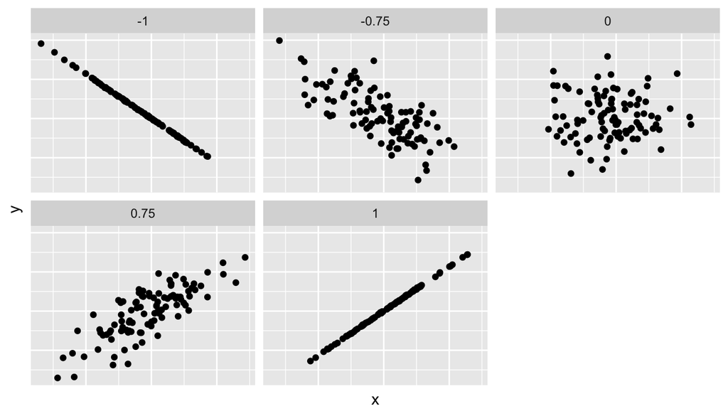

Correlation Coefficient Example

The correlation coefficient is computed using the `get_correlation()` function in the moderndive package. Here is the syntax:

```r
#your_dataframe %>%
#  get_correlation(formula = response_variable ~ explanatory_variable)

evals_onex %>%
  get_correlation(formula = score ~ bty_avg)
```

```
## # A tibble: 1 x 1
##   correlation
##         <dbl>
## 1       0.187
```

Another way to get the correlations is:

```r
cor(x = evals_onex$bty_avg, y = evals_onex$score)
```

```
## [1] 0.1871424
```

In our case, the correlation coefficient of 0.187 indicates that the linear relationship between teaching evaluation score and beauty average is “weakly positive.”

Properties of $r$

1. $-1 \leq r \leq 1$
2. r has no units
3. Interchanging $x$ and $y$ does not change $r$
4. Changing the units of one variable of both would not change $r$

### 4.1.3 Visualizing the Data

Since both the `score` and `bty_avg` variables are numerical, a *scatter plot* is an appropriate graph to visualize this data.

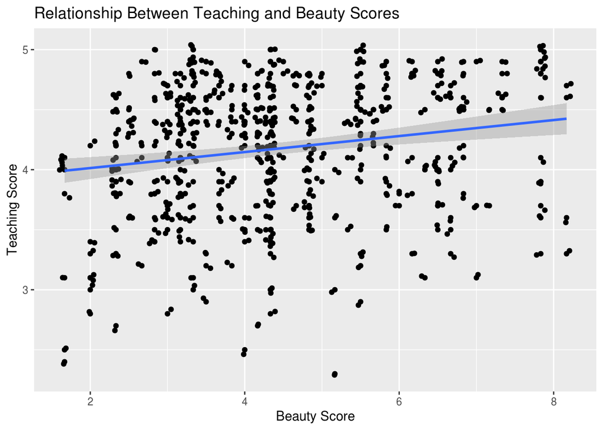

```r
library(ggplot2)
ggplot(data = evals_onex, mapping = aes(x = bty_avg, y = score)) +
    geom_point() +
    geom_jitter() +
    labs(x = "Beauty Score", y = "Teaching Score", title = "Relationship Between Teaching and Beauty Scores") +
    geom_smooth(method = "lm")
```

```r
#compute summary statistics
evals %>%
  select(score, age) %>%
  skim()
```

```
## Skim summary statistics
##  n obs: 463
##  n variables: 2
##
## ── Variable type:integer ─────────────────────────────────────────────────────────────────────────────────────
##  variable missing complete   n  mean  sd p0 p25 p50 p75 p100     hist
##       age       0      463 463 48.37 9.8 29  42  48  57   73 ▅▅▅▇▅▇▂▁
##
## ── Variable type:numeric ─────────────────────────────────────────────────────────────────────────────────────
##  variable missing complete   n mean   sd  p0 p25 p50 p75 p100     hist
##     score       0      463 463 4.17 0.54 2.3 3.8 4.3 4.6    5 ▁▁▂▃▅▇▇▆
```

```r
# According to the histograms: variable score is skewed to the left, and the variable age is uniformly distributed
#The mean teaching score was 4.17 out of 5 whereas the mean age was 48.37
#The median teaching score was 4.3 out of 5 whereas the median age was 48
#Furthermore, the middle 50% of teaching scores were between 3.8 and 4.6
# while the middle 50% of ages were between 42 and 57

#get correlation
cor(x = evals$age, y = evals$score)
```

```
## [1] -0.107032
```

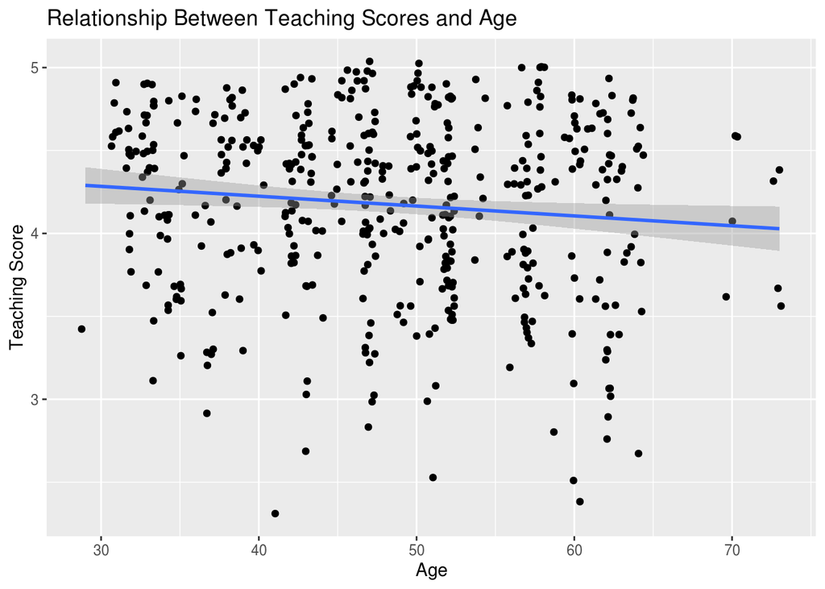

```r
#score and age have a slight negative correlation
#older teachers have slighty lower teaching scores than younger teachers

#visualization
ggplot(data = evals, mapping = aes(x = age, y = score)) +
    geom_jitter() +
    labs(x = "Age", y = "Teaching Score", title = "Relationship Between Teaching Scores and Age") +
    geom_smooth(method = "lm")
```

## 4.2 Simple linear regression

The equation of the regression line is $\hat{y} = b_0+b_1\cdot x$ where…

- the intercept coefficient is $b_0$ is the average value of $\hat{y}$ when $x=0$, and
- the slope coefficient $b_1$ is the increase in $\hat{y}$ for every one unit increase in $x$.

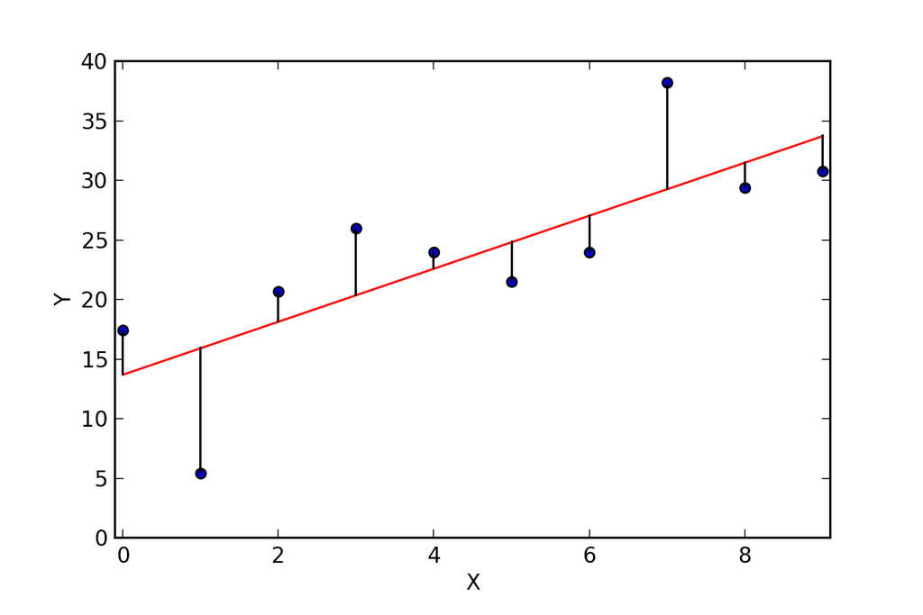

Regression Coefficient Example

The vertical distances from the points to the line are called the *residuals*. We obtain the line by minimizing the sum of the squares of the distances from the points to the line. If we denote the observed points by $y_i$ and the opints on the line by $\hat{y_i}$. Then the reiduals can be denoted by $y_i-\hat{y_i}$. So we obtain the line ($b_0$ and $b_1$), by minimizing the following quantity

$\texttt{Residual sum of squares} = \sum(y_i-\hat{y_i})^2$

### 4.2.1 How to use R to get $b_0$ and $b_1$ values.

The `lm()` function that “fits” the linear regression model is typically used as `lm(y ~ x, data = data_frame_name)` where:

- `y` is the outcome variable, followed by a tilde (`~`). In our case, `y` is set to `score`.
- `x` is the explanatory variable. In our case, `x` is set to `bty_avg`. We call the combination `y ~ x` a model formula.
- `data_frame_name` is the name of the data frame that contains the variables `y` and `x`. In our case, `data_frame_name` is the `evals_onex` data frame.

```r
score_model <- lm(score ~ bty_avg, data = evals_onex) #y ~ x
score_model
```

```
##
## Call:
## lm(formula = score ~ bty_avg, data = evals_onex)
##
## Coefficients:
## (Intercept)      bty_avg
##     3.88034      0.06664
```

This output is telling us that the Intercept coefficient $b_0$ of the regression line is 3.8803 and the slope coefficient ($b_1$) for bty_avg is 0.0666. Therefore the blue regression line is (line in the previous figure)

$\hat{\text{score}} = b_0 + b_1 \cdot \text{bty_avg}$

$\hat{\text{score}} = 3.8803 + 0.0666 \cdot \text{bty_avg}$

Interpretations of $b_0$ and $b_1$:

- The intercept coefficient $b_0=3.8803$:

For instructors who with beauty score of 0, we would expect to have on average a teaching score of 3.8803. In this case interpretaion of $b_0$ is meaningless. (Why?)

```r
Range <- range(evals_onex$bty_avg)
Range
```

```
## [1] 1.667 8.167
```

`bty_avg` of 0 is outside the range of `bty_avg` values

This is a numerical quantity that summarizes the relationship between the outcome and explanatory variables. Note that the sign is positive, suggesting a positive relationship between beauty scores and teaching scores, meaning as beauty scores go up, so also do teaching scores go up. The slope’s precise interpretation is:

> For every of 1 unit increase in `bty_avg`, there is an associated increase of, on average, 0.0666 ($b_1$) units of `score`.
1. Predict the teaching score if the beauty average is 7.5:
2. Predict the teaching score if the beauty average is 9.1:

```r
score1 = 3.8803 + 0.0666 * (7.5)
score1
```

```
## [1] 4.3798
```

$\hat{score} = 3.8803 + 0.0666 \times 7.5 = 4.3798$

*Extrapolation* is using the regression to predict $y$ from $x$ outside the range of x values. Such predictions are often not accurate.

```r
score2 = 3.8803 + 0.0666 * (9.1)
score2
```

```
## [1] 4.48636
```

Fit a new simple linear regression for score where `age` is the new explanatory variable $x$.

Interpret the regression coefficients.

```r
age_model = lm(score ~ age, data = evals)
age_model
```

```
##
## Call:
## lm(formula = score ~ age, data = evals)
##
## Coefficients:
## (Intercept)          age
##    4.461932    -0.005938
```

$\hat{score} = 4.461932 - 0.005938 \cdot age$

## 4.3 Observed, fitted values and residuals

- Observed values: Usually the $y$ values from the dataset
- Fitted values: $\hat{y}$ values we get from the model($\hat{y} = b_0+b_1\cdot x$)
- Residuals: Difference between Observed and Fitted values = $y-\hat{y}$

Let’s only consider one observation: For example, say we are interested in the 21st instructor in this dataset:

```r
kable(evals_onex[21,])
```

| score | bty_avg |
| --- | --- |
| 4.9 | 7.333 |

Here in this example:

- Observed value = $y=4.9$
- Fitted value = $\hat{y}=3.8803+0.0666\cdot7.333=4.368678$
- Residual = $y-\hat{y}=4.9-4.368678=0.531322$

Now, when we have to find residuals for all the values (not just one). R can do it for us…

```r
regression_points <- get_regression_points(score_model)
regression_points
```

```
## # A tibble: 463 x 5
##       ID score bty_avg score_hat residual
##    <int> <dbl>   <dbl>     <dbl>    <dbl>
##  1     1   4.7    5         4.21    0.486
##  2     2   4.1    5         4.21   -0.114
##  3     3   3.9    5         4.21   -0.314
##  4     4   4.8    5         4.21    0.586
##  5     5   4.6    3         4.08    0.52
##  6     6   4.3    3         4.08    0.22
##  7     7   2.8    3         4.08   -1.28
##  8     8   4.1    3.33      4.10   -0.002
##  9     9   3.4    3.33      4.10   -0.702
## 10    10   4.5    3.17      4.09    0.409
## # … with 453 more rows
```

### 4.3.1 Diagnostics (Residual Plot)

The plot of residuals against the fitted values ($\hat{y}$, $y_i-\hat{y_i}$) provides infomation on the appropriateness of a *straight-line* model. Ideally, points should be scattered randomly about the reference line $y=0$ See the following Figure.

Residual plots are useful for the followings:

- Revealing curvature – that is, for indicating that the relationship between the two variables is not linear.
- Spotting outliers.

Example: Create a residul plot for the `score_model` and interpret the residial plot.

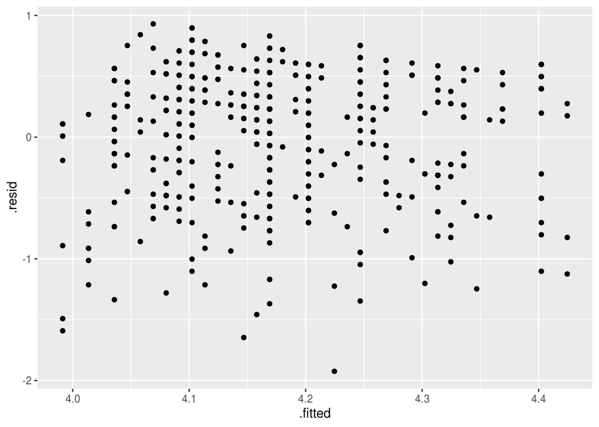

```r
ggplot(score_model, aes(x = .fitted, y = .resid)) + geom_point()
```

Plotted points are scattered randomly (no pattern) about the reference line $residual=0$. Also, no outliers are detected. Therefore the residual plot indicate that the relationship between `bty_avg` and `score` is linear.

Example: Create a residul plot for the model where y=score and x=age and interpret the residial plot.

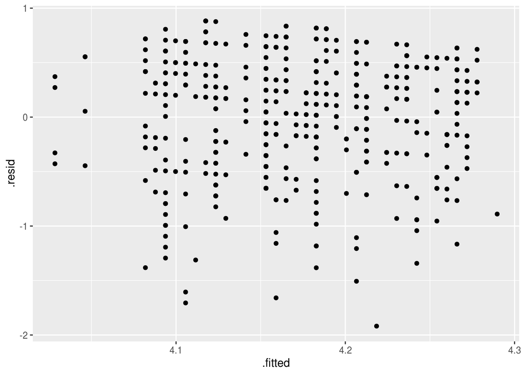

```r
ggplot(age_model, aes(x = .fitted, y = .resid)) + geom_point()
```

## 4.4 One categorical explanatory variable

When the explanatory variable $x$ is categorical, the concept of a “best-fitting” line is a little different than the one we saw in the previous Section where the explanatory variable $x$ was numerical.

We use the following example to study this.

It’s an unfortunate truth that life expectancy is not the same across various countries in the world; there are a multitude of factors that are associated with how long people live. International development agencies are very interested in studying these differences in the hope of understanding where governments should allocate resources to address this problem. In this section, we’ll explore differences in life expectancy in two ways:

1. Differences between continents: Are there significant differences in life expectancy, on average, between the five continents of the world: Africa, the Americas, Asia, Europe, and Oceania?
2. Differences within continents: How does life expectancy vary within the world’s five continents? For example, is the spread of life expectancy among the countries of Africa larger than the spread of life expectancy among the countries of Asia?

To answer such questions, we’ll study the `gapminder` dataset in the `gapminder package`. This dataset has international development statistics such as life expectancy, GDP per capita, and population by country ($n = 142$) for 5-year intervals between 1952 and 2007.

We’ll use this data for linear regression again, but note that our explanatory variable $x$ is now *categorical*, and not numerical like when we covered simple linear regression in Section 6.1. More precisely, we have:

1. A numerical outcome variable $y$. In this case, life expectancy.
2. A single categorical explanatory variable $x$, In this case, the continent the country is part of.

As always, the first step in model building is…

1. Type `View(gapminder)` in the console.

Let’s load the `gapminder` data and `filter()` for only observations in 2007. Next we `select()` only the variables `country`, `continent`, `lifeExp`, along with `gdpPercap`, which is each country’s gross domestic product per capita (GDP). GDP is a rough measure of that country’s economic performance. Lastly, we save this in a data frame with name `gapminder2007`:

```r
library(gapminder)
data(gapminder)
str(gapminder)
```

```
## Classes 'tbl_df', 'tbl' and 'data.frame':    1704 obs. of  6 variables:
##  $ country  : Factor w/ 142 levels "Afghanistan",..: 1 1 1 1 1 1 1 1 1 1 ...
##  $ continent: Factor w/ 5 levels "Africa","Americas",..: 3 3 3 3 3 3 3 3 3 3 ...
##  $ year     : int  1952 1957 1962 1967 1972 1977 1982 1987 1992 1997 ...
##  $ lifeExp  : num  28.8 30.3 32 34 36.1 ...
##  $ pop      : int  8425333 9240934 10267083 11537966 13079460 14880372 12881816 13867957 16317921 22227415 ...
##  $ gdpPercap: num  779 821 853 836 740 ...
```

```r
gapminder2007 = gapminder %>%
    filter(year == 2007) %>%
    select(country, continent, lifeExp, gdpPercap)

glimpse(gapminder2007)
```

```
## Observations: 142
## Variables: 4
## $ country   <fct> Afghanistan, Albania, Algeria, Angola, Argentina, Aust…
## $ continent <fct> Asia, Europe, Africa, Africa, Americas, Oceania, Europ…
## $ lifeExp   <dbl> 43.828, 76.423, 72.301, 42.731, 75.320, 81.235, 79.829…
## $ gdpPercap <dbl> 974.5803, 5937.0295, 6223.3675, 4797.2313, 12779.3796,…
```

Notice that variable `continent` is indeed categorical.

Let’s apply the `skim()` function from the `skimr` package to our two variables of interest: `continent` and `lifeExp`:

```r
library(skimr)
gapminder2007 %>%
    select(continent, lifeExp) %>%
    skim()
```

```
## Skim summary statistics
##  n obs: 142
##  n variables: 2
##
## ── Variable type:factor ──────────────────────────────────────────────────────────────────────────────────────
##   variable missing complete   n n_unique
##  continent       0      142 142        5
##                          top_counts ordered
##  Afr: 52, Asi: 33, Eur: 30, Ame: 25   FALSE
##
## ── Variable type:numeric ─────────────────────────────────────────────────────────────────────────────────────
##  variable missing complete   n  mean    sd    p0   p25   p50   p75 p100
##   lifeExp       0      142 142 67.01 12.07 39.61 57.16 71.94 76.41 82.6
##      hist
##  ▂▂▂▂▂▃▇▇
```

Given that the global median life expectancy is **71.94**, half of the world’s countries (**71** countries) will have a life expectancy less than **71.94**. Further, half will have a life expectancy greater than this value. The mean life expectancy of **67.01** is lower however. Why are these two values different? Let’s look at a histogram of `lifeExp` to see why.

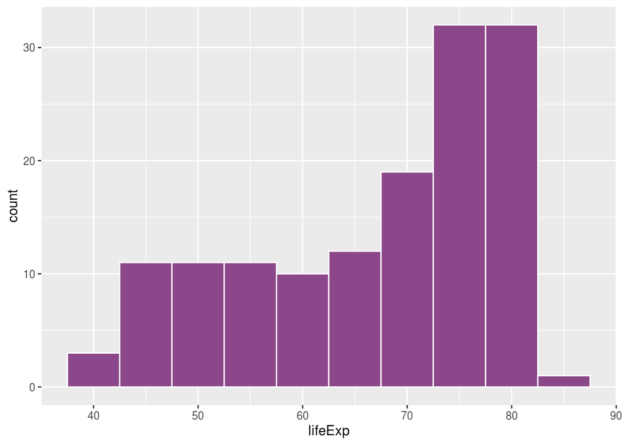

```r
ggplot(data = gapminder2007, mapping = aes(x = lifeExp)) +
  geom_histogram(binwidth = 5, color='white', fill='orchid4')
```

We see that this data is skewed to the **left**: there are a few countries with very low life expectancy that are bringing down the **mean** life expectancy. However, the **median** is less sensitive to the effects of such outliers. Hence the **median** is greater than the **mean** in this case.

```r
tbl = gapminder2007 %>%
    group_by(continent) %>%
    summarize(median = median(lifeExp), mean = mean(lifeExp), N = n())
kable(tbl)
```

| continent | median | mean | N |
| --- | --- | --- | --- |
| Africa | 52.9265 | 54.80604 | 52 |
| Americas | 72.8990 | 73.60812 | 25 |
| Asia | 72.3960 | 70.72848 | 33 |
| Europe | 78.6085 | 77.64860 | 30 |
| Oceania | 80.7195 | 80.71950 | 2 |

Let’s create a corresponding visualization.

1. Compare the life expectancy of countries in different continents via a faceted histogram.

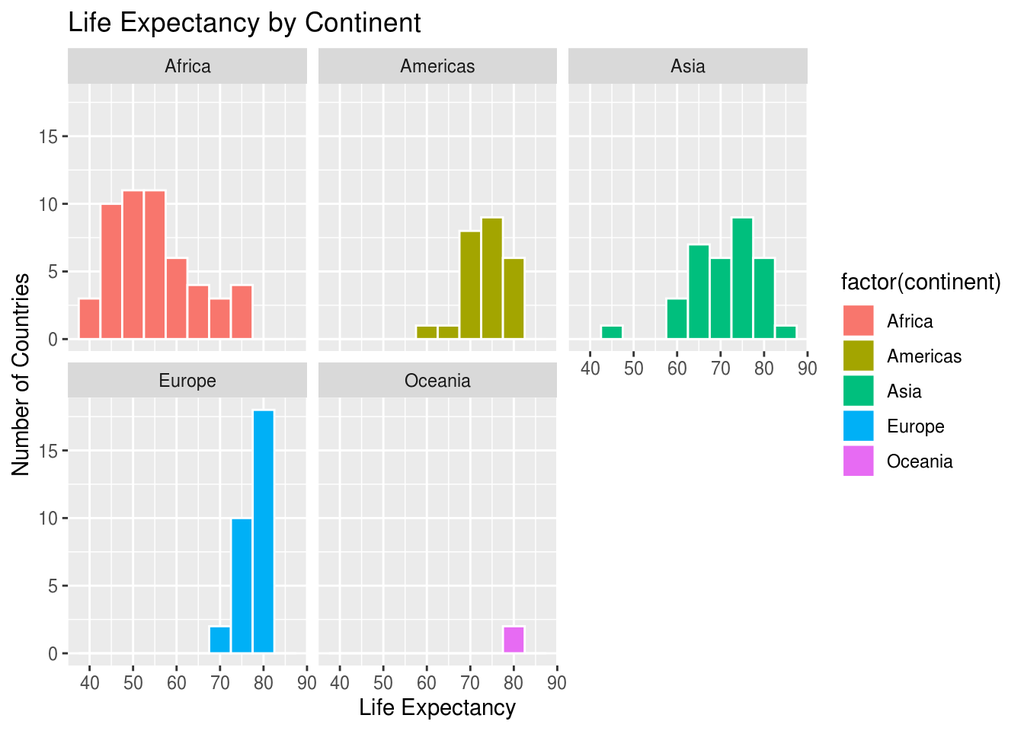

```r
ggplot(data = gapminder2007, mapping = aes(x = lifeExp, fill = factor(continent))) +
    geom_histogram(binwidth = 5, color = 'white') +
    labs(x = "Life Expectancy", y = "Number of Countries", title = "Life Expectancy by Continent") +
    facet_wrap(~ continent, nrow = 2)
```

2. Compare the life expectancy of countries in different continents via side-by-side box plots.

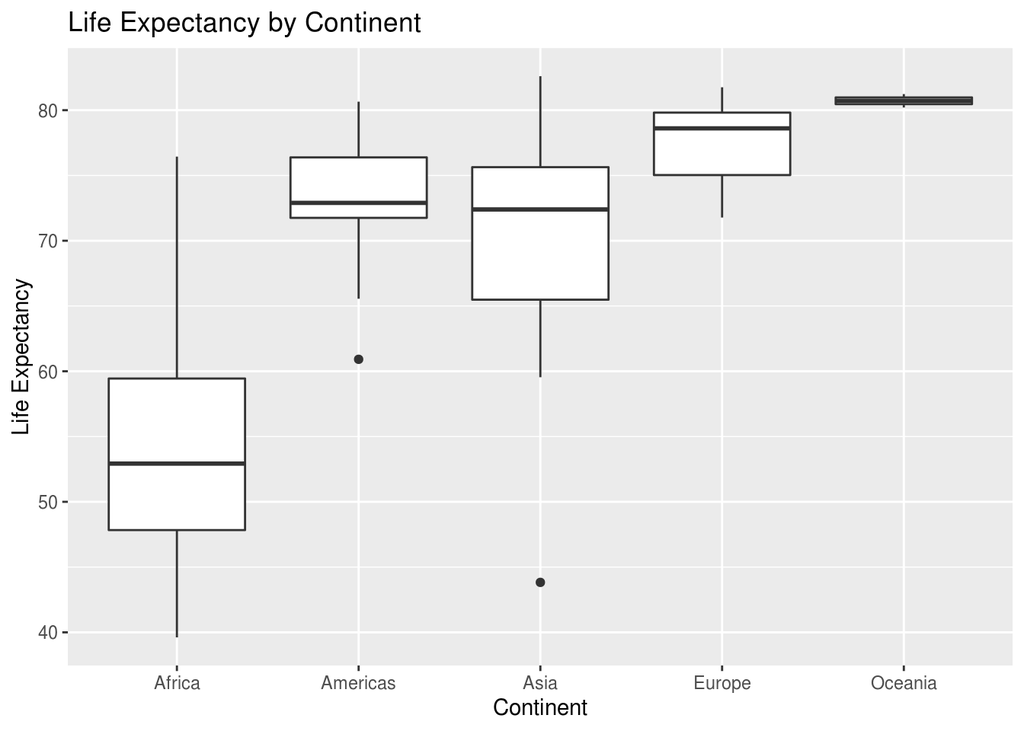

```r
ggplot(data = gapminder2007, aes(x = continent, y = lifeExp)) +
    geom_boxplot() +
    labs(x = "Continent", y = "Life Expectancy", title = "Life Expectancy by Continent")
```

- For example, half of all countries in Asia have a life expectancy below $72.396$ years whereas half of all countries in Asia have a life expectancy above $72.396$ years. (This is because the Median life expectancy for the countries in Asia is $72.396$).
- Furthermore, note that: Africa and Asia have much more spread/variation in life expectancy as indicated by the *IQR* (the height of the boxes).
- Oceania has almost no spread/variation, but this might in large part be due to the fact there are only two countries in Oceania: Australia and New Zealand.

Now, let’s start making comparisons of life expectancy between continents.

First we have to pick a *baseline* to compare with. Let’s use Africa.

- We can see that even the country with the highest life expectancy in Africa is still lower than all countries in *Oceania*.
- We can see that even the country with the highest life expectancy in Africa is still lower than the median life expectancy of the countries in *Europe*.
- The median life expectancy of the Americas is roughly 20 years greater.
- The median life expectancy of Asia is roughly 20 years greater.
- The median life expectancy of Europe is roughly 25 years greater.
- The median life expectancy of Oceania is roughly 27.8 years greater.

### 4.4.1 Linear regression

In section 6.1 we introduced *simple linear* regression, which involves modeling the relationship between a numerical outcome variable $y$ as a function of a numerical explanatory variable $x$, in our life expectancy example, we now have a *categorical explanatory variable* $x$ continent.

While we still can fit a regression model, given our categorical explanatory variable we no longer have a concept of a *“best-fitting”* line, but rather *“differences relative to a baseline for comparison.”*

Before we fit our regression model, let’s create a table similar to the previous table, but…

1. Report the mean life expectancy for each continent.
2. Report the difference in mean life expectancy relative to Africa’s mean life expectancy of $54.806$ in the column “mean vs Africa”; this column is simply the “mean” column minus $54.806$.

```r
meanAfrica = 54.806
tbl = gapminder2007 %>%
    group_by(continent) %>%
    summarize(mean = round(mean(lifeExp),3), vsAfrica = round(mean(lifeExp),3)-meanAfrica)
kable(tbl)
```

| continent | mean | vsAfrica |
| --- | --- | --- |
| Africa | 54.806 | 0.000 |
| Americas | 73.608 | 18.802 |
| Asia | 70.728 | 15.922 |
| Europe | 77.649 | 22.843 |
| Oceania | 80.719 | 25.913 |

Now, let’s use the `lm` function we introduced in Section 6.1 to get the regression coefficients for `gapminder2007` analysis:

```r
lifeExp_model <- lm(lifeExp ~ continent, data = gapminder2007)
lifeExp_model
```

```
##
## Call:
## lm(formula = lifeExp ~ continent, data = gapminder2007)
##
## Coefficients:
##       (Intercept)  continentAmericas      continentAsia
##             54.81              18.80              15.92
##   continentEurope   continentOceania
##             22.84              25.91
```

```r
summary(lifeExp_model)
```

```
##
## Call:
## lm(formula = lifeExp ~ continent, data = gapminder2007)
##
## Residuals:
##      Min       1Q   Median       3Q      Max
## -26.9005  -4.0399   0.2565   3.3840  21.6360
##
## Coefficients:
##                   Estimate Std. Error t value Pr(>|t|)
## (Intercept)         54.806      1.025  53.446  < 2e-16 ***
## continentAmericas   18.802      1.800  10.448  < 2e-16 ***
## continentAsia       15.922      1.646   9.675  < 2e-16 ***
## continentEurope     22.843      1.695  13.474  < 2e-16 ***
## continentOceania    25.913      5.328   4.863 3.12e-06 ***
## ---
## Signif. codes:  0 '***' 0.001 '**' 0.01 '*' 0.05 '.' 0.1 ' ' 1
##
## Residual standard error: 7.395 on 137 degrees of freedom
## Multiple R-squared:  0.6355, Adjusted R-squared:  0.6249
## F-statistic: 59.71 on 4 and 137 DF,  p-value: < 2.2e-16
```

What are these values? First, we must describe the equation for fitted value $\hat{y}$, which is a little more complicated when the $x$ explanatory variable is categorical:

$\hat{\text{life exp}} = b_0 + b_{Amer} \cdot 1_{Amer}(x) + b_{Asia} \cdot 1_{Asia}(x) + b_{Euro} \cdot 1_{Euro}(x) + b_{Ocean} \cdot 1_{Ocean}(x)$

$\hat{\text{life exp}} = 54.81 + 18.80 \cdot 1_{Amer}(x) + 15.92 \cdot 1_{Asia}(x) + 22.84 \cdot 1_{Euro}(x) + 25.91 \cdot 1_{Ocean}(x)$

What does $1_{A}(x)$ mean? (from your previous math course)

In mathematics this is known as an “indicator function” that takes one of two possible values:

$1_{A}(x) = \begin{cases} 1 & x \in A \\ 0 & x \notin A \end{cases}$

In a statistical modeling context this is also known as a “dummy variable”. In our case, let’s consider the first such indicator variable:

$1_{Amer}(x) = \begin{cases} 1 & \text{if country x is in the Americas} \\ 0 & \text{otherwise} \end{cases}$

Now let’s interpret the regression coefficients.

1. First $b_0 = intercept = 54.8$: the mean life expectancy for countries in Africa, because Africa was our baseline.
2. $b_{Amer} = continentAmericas = 18.8$: the difference in mean life expectancy of countries in the Americas relative to Africa, or in other words, on average countries in the Americas had life expectancy 18.8 years greater.

The fitted value yielded by this equation is: (i.e. in this case, only the indicator function $1_{Amer}(x)$ is equal to 1, but all others are 0.

$\hat{\text{life exp}} = 54.81 + 18.80 \cdot 1_{Amer}(x) + 15.92 \cdot 1_{Asia}(x) + 22.84 \cdot 1_{Euro}(x) + 25.91 \cdot 1_{Ocean}(x)$

$\hat{\text{life exp}} = 54.81 + 18.80 \cdot 1 + 15.92 \cdot 0 + 22.84 \cdot 0 + 25.91 \cdot 0$

$\hat{\text{life exp}} = 54.81 + 18.80$

Furthermore, this value corresponds to the group mean life expectancy for all American countries.

- Similarly, $b_{Asia} = continentAsia = 15.9$. Interpret this: the difference in mean life expectancy of countries in Asia relative to Africa had life expectancy $15.9$ years greater
- $b_{Euro} = continentEurope = 22.84$: the difference in mean life expectancy of countries in Europe relative to Africa had life expectancy $22.84$ years greater
- $b_{Ocean} = continentOceania = 25.91$: the difference in mean life expectancy of countries in Oceania relative to Africa had life expectancy $25.91$ years greater

Rest of the coefficients can be interpreted the same way.

Let’s generalize…

- If we fit a linear regression model using a categorical explanatory variable $x$ that has $k$ levels, a regression model will return an intercept and $k−1$ “slope” coefficients.
- When $x$ is a numerical explanatory variable the interpretation is of a “slope” coefficient
- When $x$ is categorical the meaning is a little trickier. They are “offsets” relative to the baseline.

## 4.5 Example

1. Fit a new linear regression to predict the GDP using continent using the `gapminder2007` dataframe.
2. Write the model.
3. Interpret the coefficients.

```r
gdpPercap_model <- lm(gdpPercap ~ continent, data = gapminder2007)
gdpPercap_model
```

```
##
## Call:
## lm(formula = gdpPercap ~ continent, data = gapminder2007)
##
## Coefficients:
##       (Intercept)  continentAmericas      continentAsia
##              3089               7914               9384
##   continentEurope   continentOceania
##             21965              26721
```

```r
summary(gdpPercap_model)
```

```
##
## Call:
## lm(formula = gdpPercap ~ continent, data = gapminder2007)
##
## Residuals:
##    Min     1Q Median     3Q    Max
## -19117  -5681  -1905   3945  34834
##
## Coefficients:
##                   Estimate Std. Error t value Pr(>|t|)
## (Intercept)           3089       1373   2.250 0.026025 *
## continentAmericas     7914       2409   3.285 0.001295 **
## continentAsia         9384       2203   4.259 3.79e-05 ***
## continentEurope      21965       2270   9.678  < 2e-16 ***
## continentOceania     26721       7133   3.746 0.000264 ***
## ---
## Signif. codes:  0 '***' 0.001 '**' 0.01 '*' 0.05 '.' 0.1 ' ' 1
##
## Residual standard error: 9899 on 137 degrees of freedom
## Multiple R-squared:  0.4243, Adjusted R-squared:  0.4075
## F-statistic: 25.24 on 4 and 137 DF,  p-value: 1.127e-15
```

> $\hat{\text{GDP}} = 3089 + 7914 \cdot 1_{Amer}(x) + 9384 \cdot 1_{Asia}(x) + 21965 \cdot 1_{Euro}(x) + 26721 \cdot 1_{Ocean}(x)$
- $b_{Amer} = continentAmericas = 7914$: the difference in mean GDP of countries in the Americas relative to Africa is $7914$ dollars greater
- $b_{Asia} = continentAsia = 9384$: the difference in mean GDP of countries in Asia relative to Africa is $9384$ dollars greater
- $b_{Euro} = continentEurope = 21965$: the difference in mean GDP of countries in Europe relative to Africa is $21965$ dollars greater
- $b_{Ocean} = continentOceania = 26721$: the difference in mean GDP of countries in Oceania relative to Africa is $26721$ dollars greater